# Week 6 - Midterm Assignment: A Simulation Project

STAT 420, Summer 2021,Alejandro Pimentel (ap41)

# Simulation Study 3: Power

## Introduction

In this simulation study we will investigate the **power** of the significance of regression test for simple linear regression.

$$H_0: \beta_{1} = 0 \ \text{vs} \ H_1: \beta_{1} \neq 0$$

Recall, we had defined the *significance* level, $\alpha$, to be the probability of a Type I error.

$$\alpha = P[\text{Reject } H_0 \mid H_0 \text{ True}] = P[\text{Type I Error}]$$

Similarly, the probability of a Type II error is often denoted using $\beta$; however, this should not be confused with a regression parameter.

$$\beta = P[\text{Fail to Reject } H_0 \mid H_1 \text{ True}] = P[\text{Type II Error}]$$

*Power* is the probability of rejecting the null hypothesis when the null is not true, that is, the alternative is true and $\beta_{1}$ is non-zero.

$$\text{Power} = 1 - \beta = P[\text{Reject } H_0 \mid H_1 \text{ True}]$$

Essentially, power is the probability that a signal of a particular strength will be detected. Many things affect the power of a test. In this case, some of those are:

- Sample Size, $n$
- Signal Strength, $\beta_1$
- Noise Level, $\sigma$
- Significance Level, $\alpha$

We’ll investigate the first three.

To do so we will simulate from the model

$$Y_i = \beta_0 + \beta_1 x_i + \epsilon_i$$

where $\epsilon_i \sim N(0, \sigma^2)$.

For simplicity, we will let $\beta_0 = 0$, thus $\beta_1$ is essentially controlling the amount of “signal.” We will then consider different signals, noises, and sample sizes:

- $\beta_1 \in (-2, -1.9, -1.8, \ldots, -0.1, 0, 0.1, 0.2, 0.3, \ldots 1.9, 2)$
- $\sigma \in (1, 2, 4)$
- $n \in (10, 20, 30)$

We will hold the significance level constant at $\alpha = 0.05$.

For each possible $\beta_1$ and $\sigma$ combination, we will simulate from the true model at least $1000$ times. Each time, we will perform the significance of the regression test. To estimate the power with these simulations, and some $\alpha$, use

$$\hat{\text{Power}} = \hat{P}[\text{Reject } H_0 \mid H_1 \text{ True}] = \frac{\text{# Tests Rejected}}{\text{# Simulations}}$$

## Methods

Let’s start pre-allocating the variables we will need during the simulation.

```r
birthday <- 19820426
set.seed(birthday)

alpha <- 0.05
num_sims <- 1000
sigmas <- c(1, 2, 4)
# The 3 different sizes for the observations.
n_obs <- c(10, 20, 30)
# A sequence to get the beta_1 values.
betas_1 <- seq(-2, 2, 0.1)

# Contains our 3 sets of x values (1 predictor only)
x_values <- list(seq(0, 5, length = n_obs[1])
             ,seq(0, 5, length = n_obs[2])
             ,seq(0, 5, length = n_obs[3])
             #,seq(0, 5, length = n_obs[4])
             )

# a matrix where each (i,j) is a boolean with the result of significance test for
# the simulation_i and the x_values_j data set.
significance_results <- matrix(0, num_sims, length(x_values))

# a matrix where each (i,j) is the power of a beta_i given a x_values_j.
betas_by_powers <- matrix(0, length(betas_1), length(x_values))
```

The following function returns the `p-value` for the `Significance of Regression`. In other words the `p-value` to test Hypothesis:

$$H_0: \beta_{1} = 0 \ \text{vs} \ H_1: \beta_{1} \neq 0$$

The functions below fit a SLR model and extract the `p-value` we will use for testing the `Siginificance of the Regression`.

```r
sim_slr <- function(x, beta_0 = 0, beta_1, sigma) {
  n <- length(x)
  epsilon <- rnorm(n = n, mean = 0, sd = sigma)
  y <- beta_0 + beta_1 * x + epsilon
  lm(y ~ x)
}

get_p_val <- function(model) {
  summary(model)$coef["x", "Pr(>|t|)"]
}
```

Now we can execute the experiment for each of our 3 $\sigma$ values. Notably, we need to keep count of the `Rejections` to calculate the power after every 1000 simulations.

```r
do_prints <- FALSE
run_simulation <- function(sigma) {
  # for each beta_1
  for (bidx in 1:length(betas_1)) {
    bi <- betas_1[bidx]
    for (si in 1:num_sims) {

      # Fit a model for each set of observations.
      model_n10 <- sim_slr(x_values[[1]], beta_1=bi, sigma=sigma)
      model_n20 <- sim_slr(x_values[[2]], beta_1=bi, sigma=sigma)
      model_n30 <- sim_slr(x_values[[3]], beta_1=bi, sigma=sigma)
      p_values <- c(get_p_val(model_n10)
                    ,get_p_val(model_n20)
                    ,get_p_val(model_n30)
                    )

      # Store the test results for the ith simulation
      significance_results[si, ] <- (p_values < alpha)
      if(do_prints) {
        print(paste("beta_1=",bi,",sigma=", sigma, ",n_obs=",n_obs))
        print(p_values)
        print(p_values < alpha)
        print("************************************")
      }
    }
    # When simulations are finished for a beta, calculate the power
    powers <- colSums(significance_results) / num_sims
    # Store the powers for the ith beta
    betas_by_powers[bidx, ] <- powers
  }
  betas_by_powers
}

results_sigma1 <- run_simulation(sigmas[1])
results_sigma2 <- run_simulation(sigmas[2])
results_sigma4 <- run_simulation(sigmas[3])
```

## Results

From our simulation, we are interest in observing how the `Power` changes for the follow factors:

- Values of $\beta_1$
- Values of $\sigma$

```r
power_plot <- function(x, y1, y2, y3, sigma, title="Power Vs beta_1") {
  plot(x, y1,
       xlab = beta[1] ~ " values",
       ylab = paste("Signal Power (", num_sims, "simulations )"),
       main = paste(title," ( sigma =", sigma,")"),
       col = "darkorange",
       lwd=2.5,
       lty=2,
       #col.main='blue',
       ylim= c(0,1),
       type='o')

  lines(x, y2,
        lwd=2.5,
        lty=2,
        col='forestgreen',
        type='o')

  lines(x, y3,
        lwd=2.5,
        lty=2,
        col='darkorchid4',
        type='o')

  legend("bottomright",
         c(paste(n_obs[1], "Observations"),
           paste(n_obs[2], "Observations"),
           paste(n_obs[3], "Observations")),
       lty = c(3, 3, 3),
       lwd = 3,
       col = c("darkorange", "forestgreen", "darkorchid4"))
}
```

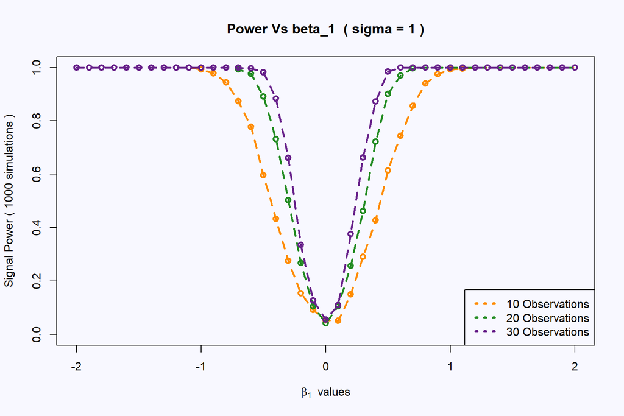

```r
par(mfrow=c(1, 1), bg="ghostwhite")
power_plot(betas_1,
           results_sigma1[ , 1],
           results_sigma1[ , 2],
           results_sigma1[ , 3],
           sigmas[1])
```

**Graph 3.1 - Power as a function of** $\beta_1$ **for 3 data sets**, $\sigma=1$

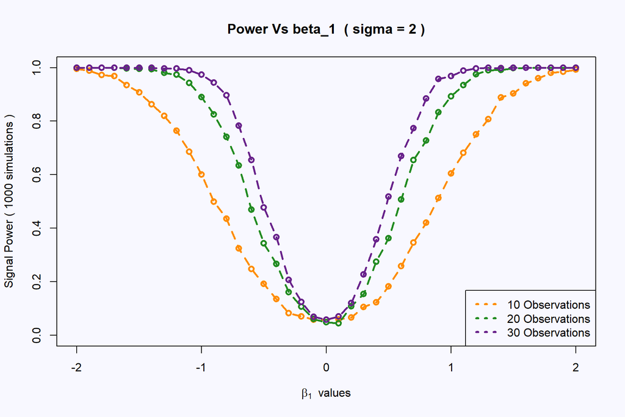

```r
par(mfrow=c(1, 1), bg="ghostwhite")
power_plot(betas_1,
           results_sigma2[ , 1],
           results_sigma2[ , 2],
           results_sigma2[ , 3],
           sigmas[2])
```

**Graph 3.2 - Power as a function of** $\beta_1$ **for 3 data sets**, $\sigma=2$

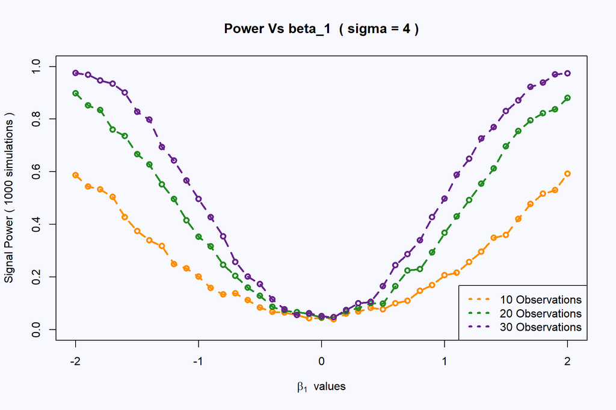

```r
par(mfrow=c(1, 1), bg="ghostwhite")
power_plot(betas_1,
           results_sigma4[ , 1],
           results_sigma4[ , 2],
           results_sigma4[ , 3],
           sigmas[3])
```

**Graph 3.3 - Power as a function of** $\beta_1$ **for 3 data sets**, $\sigma=4$

## Discussion

In the 3 graphs above we can notice a few things in common:

- As $\beta_1$ approaches 0 the `Power` also approaches 0.

We interpret this as increasing the probability of making `Type II` errors as $\beta_1$ gets smaller in magnitude. In other words, it is harder to detect the significance of a predictor if the parameter is small.

This is expected if we consider that with small values of $\beta_1$ and a fixed value of $sigma$ and degrees of freedom, it’s likely to get small values for the `F statistic`, recall that for SLR we define it as:

$$F = \frac{\sum_{i=1}^{n}(\hat{y}_i - \bar{y})^2 / 1}{\sum_{i=1}^{n}(y_i - \hat{y}_i)^2 / (n - 2)}$$
In a simpler way, the smaller $\beta_1$ is the more likely we will `Fail to Reject the Null Hypothesis`, thus, the related predictor $x_i$ seems to have less and less significance.

- With a larger number of observations the `Power` is more stable even if $\beta_1$ gets smaller or we introduce more noise to the simulation.

This is an interesting point where is clear that having more observations help us to make less errors. If we for instance consider `Graph 3.1`, the `Power Curve for 30 observations` (in purple) stays more stable as $\beta_1$ gets smaller.

We can see the same pattern repeating for `Graphs 3.2 and 3.3`.

Back to the formula to calculate `F`, when $n-2$ is larger (n being the number of observations) the `F` value would be larger.

- The `Power Curves` drop faster when $\sigma$ is larger.

A larger $\sigma$ introduces more uncertainty to the model so we are less confident of the model estimates. We are then making more `Type II` errors and having less Rejections of the `Null Hypothesis`.

`Graph 3.1` and `Graph 3.3` are an interesting contrast where is clear how the noise in the system can make easier or harder to detect a signal.

It is also interesting to think on these `Power Curves` as an upside down version of the `Normal Curves` for $\epsilon$.